# Modeling, Inference, Prediction

The MANOVA test assumes the data is composed of random samples that are independent observations, that the dependent variables have multivariate normality, that there is equal variance (homogeneity) for each dependent variable and equal covariance between any two of the dependent variables, that there is a linear relationship among the dependent variables, that there are no extreme univariate or multivariate outliers, and that there is no multicollinearity, meaning the dependent variables are not correlated. Because each of the p-values were below 0.05 after testing for multivariate normality, it’s clear that the assumptions were violated.

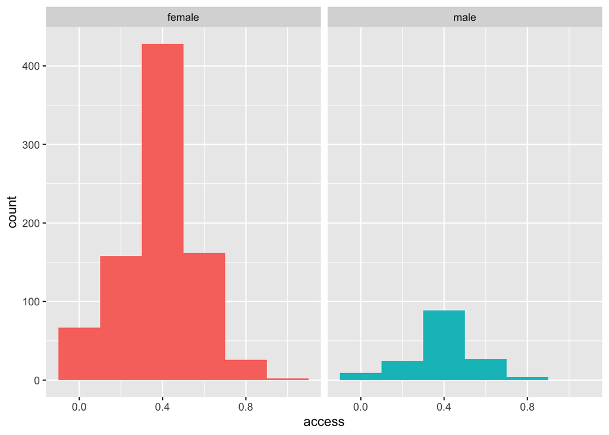

```r
# Part 2:

# Distributions are normal, so I can perform a t-test
ggplot(Medicaid,aes(access,fill=gender))+geom_histogram(bins=6.5)+
  facet_wrap(~gender,ncol=2)+theme(legend.position="none")
```

```r
# Observed test statistic (mean difference) = 0.0100414
Medicaid%>%group_by(gender)%>%
  summarize(means=mean(access))%>%summarize(`mean_diff`=diff(means))
```

```
## # A tibble: 1 × 1
##   mean_diff
##       <dbl>
## 1    0.0100
```

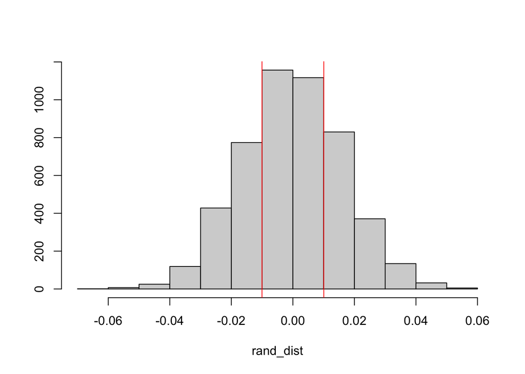

```r
# Randomization test of differences in means
rand_dist<-vector()
for(i in 1:5000){
  new<-data.frame(access=sample(Medicaid$access),gender=Medicaid$gender)
  rand_dist[i]<-mean(new[new$gender=="female",]$access) -
    mean(new[new$gender=="male",]$access)}

{hist(rand_dist,main="",ylab=""); abline(v = c(-0.0100414, 0.0100414),col="red")}
```

```r
# Two-tailed p-value
mean(rand_dist>0.0100414 | rand_dist< -0.0100414)
```

```
## [1] 0.5432
```

A randomization test testing for the mean difference of availability of services (“access”) between females and males (“gender”) was performed:

H0: The mean availability of services for males and females is the same. HA: The mean availability of services for males and females is different.

```r
# Part 3:

# Mean-centering numeric variables involved in interaction
Medicaid$access_c <- Medicaid$access - mean(Medicaid$access)
Medicaid$visits_c <- Medicaid$visits - mean(Medicaid$visits)


# Linear regression model, response variable from the predictor variable, data=*dataset*
Medicaid_lm<-lm(health1 ~ visits_c*access_c, data=Medicaid)
summary(Medicaid_lm)
```

```
##
## Call:
## lm(formula = health1 ~ visits_c * access_c, data = Medicaid)
##
## Residuals:
##     Min      1Q  Median      3Q     Max
## -4.1986 -1.0386 -0.2529  0.8129  5.9543
##
## Coefficients:
##                     Estimate Std. Error t value Pr(>|t|)
## (Intercept)        0.0009847  0.0437477   0.023  0.98205
## visits_c           0.1185798  0.0133815   8.861  < 2e-16 ***
## access_c          -0.6759206  0.2373204  -2.848  0.00449 **
## visits_c:access_c -0.0548461  0.0682623  -0.803  0.42190
## ---
## Signif. codes:  0 '***' 0.001 '**' 0.01 '*' 0.05 '.' 0.1 ' ' 1
##
## Residual standard error: 1.38 on 992 degrees of freedom
## Multiple R-squared:  0.08032,    Adjusted R-squared:  0.07754
## F-statistic: 28.88 on 3 and 992 DF,  p-value: < 2.2e-16
```